# 2324-MA378 : Lab 1 - MATLAB Primer.

This is a primer for Lab 1 of MA378 (Numerical Analysis II). You should read through this and experiement before you start the Exercises in Lab 1. For more, see https://www.niallmadden.ie/2324-MA378

Please send any comments, corrections and suggestions to Niall Madden at Niall.Madden@UniversityOfGalway.ie

# What are MATLAB and Octave?

MATLAB is a commercial computing system and programming language for scientific computing. It is especially good a working with matrices (MATLAB = "Matrix Laboratory") Octave is a free system that is largely consisitent with MATLAB. We are using Octave.

Actually, we are using Jupyter connected to a Octave kernel. You don't have to worry about what that means, except to know that it does not come with a spell-checker!

# Everything is a vector

In Matlab, just about everything is a vector. In this lab, we are mainly interested in defining vectors the represent interpolation points. If, for example, we wanted to define a vector of points between 0 and 2, with gaps of 0.5, we could do in several ways. The first is to just list all the points, using `[` and `]` to mark the start and end of the vector:

```matlab
x = [0, .5, 1, 1.5, 2]
```

[output not shown]

The second is the use the colon notation, which is `start:step:end`.

```matlab
x = 0:0.5:2
```

```
x =

         0    0.5000    1.0000    1.5000    2.0000
```

Finally, there is a function called `linspace()`, which uses the syntax `linspace(a, b, n)`, to creates a vector with $n$ equally spaced points between $a$ and $b$.

```matlab
x = linspace(0,2,5) % this one is more useful later
```

```
x =

        0   0.5000   1.0000   1.5000   2.0000
```

MATLAB indexes vectors from 1. So the first, 2rd and 4th elements of the vector we just defined are

```matlab
x(1), x(2), x(4)
```

```
ans = 0
ans = 0.5000
ans = 1.5000
```

So be careful: in lectures, we've denoted the interpolation points $\{x_0, x_1, \dots, x_N\}$. But in MATLAB/Octave they are `[x(1), x(2), ..., x(N+1)]`.

## Vector arithmetic

One of MATLAB's great strengths is that it is easy to compute new vectors from old ones. For example, we can set

```matlab
y = cos(x)
```

```
y =

   1.000000   0.877583   0.540302   0.070737  -0.416147
```

This has the effect of setting `y(1)=cos(x(1))`, `y(2)=cos(x(2))`, etc.

More generally, we can combine vectors using the standard standard arithmetic operators: `+`, `-`, `*` and `/`. For any vector, `x`, the expression

```matlab
y = 2*x +3
```

```
y =

   3   4   5   6   7
```

sets `y(i) = 2*x(i) + 3`.

Multiplication and devision are a little more tricky. For example, mathematically, the expression `z=x*y` would make no sense, because you can't multiply two (row) vectors).

But we can use the "dot" operators: `.*` and `./` for "*entrywise* multiplication and devision of vectors of the same length.

That is `z = x.*y` sets `z(i) = x(i)*y(i)` for each `i`.

The dot operator also works for exponents:

```matlab
y = x.^2
```

```
y =

        0   0.2500   1.0000   2.2500   4.0000
```

sets $y_i = x_i^2$.

You can also apply standard mathematics functions, such as `log()`, `exp()`, `sin()`, `cos()`, `abs()`, etc. to vectors, and they will return vectors.

## Getting output (or not)

MATLAB and Octave are interpretive languages (like Python). You can run your code one line at a time. If a line ends with a semi-colon, then the result of the computation is not shown. If the vectors are very big, we usually end lines with a semi-colon. We can also check the value of the variable using the `disp()` function.

```matlab
disp(x)
```

```
        0   0.5000   1.0000   1.5000   2.0000
```

## Plotting vectors

We can plot sets of points as follows. Assmung the vectors `x` and `y` are already defined, and are of the same length:

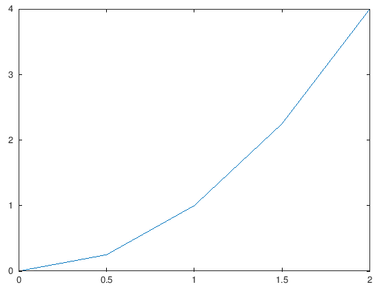

```matlab
plot(x,y)
```

Often we want a little more control over:

- colour of the line
- line style (e.g., continuous, dashed)
- how points are displated
- line width.

See if you can work out why this line of code gives the output it does:

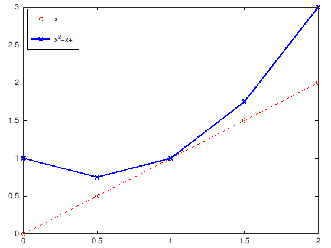

```matlab
plot(x,x, 'r--o', x, x.^2-x+1, 'b-x', 'LineWidth',4)
legend('x', 'x^2-x+1', 'location', 'northwest')
```

## What Else?

Is there something that you think you need to be able to do in MATLAB/Octave in order to complete these labs, or investigate some aspect of MA378? If so, let Niall.Madden@UniversityOfGalway.ie know.